# Overview of ggplot geoms and extensions

We will go through some examples of the charts we can make with ggplot. We will start with a basic chart and add some nice features usually not easily available in Excel.

## geom_line

```r
library(tidyverse)
source("utils.R")
df <- data.table::fread("data/gdp2v.csv") %>%
  mutate( country = str_sub(geo,1,2),
          NUTS = str_length(geo)-2) %>%
  filter(country == "AT" & NUTS == "2" & unit == "PPS_HAB_EU27_2020")
```

A simple one with no colours.

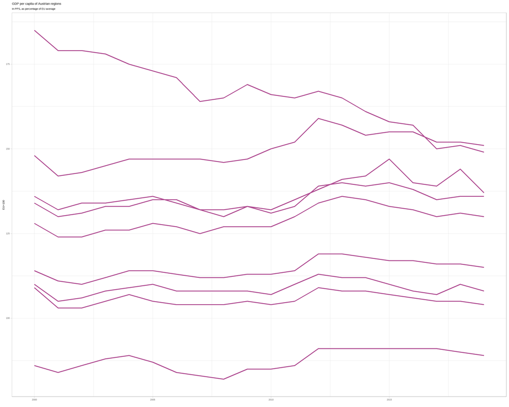

```r
p <- ggplot(df, aes(time, obs_value, group = geo))+
  geom_line(colour = luis_cols("theme2"), size = 1)+
  theme_light()+
  labs(y = "EU=100",
       x="",
       title = "GDP per capita of Austrian regions",
      subtitle =  "In PPS, as percentage of EU average")
p
```

A simple one with colours.

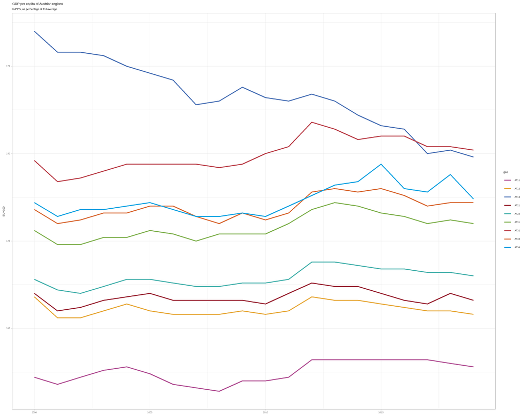

```r
p <- ggplot(df, aes(time, obs_value, colour = geo))+
  geom_line(size = 1)+
  scale_colour_luis()+
  theme_light()+
  labs(y = "EU=100",
       x="",
       title = "GDP per capita of Austrian regions",
      subtitle =  "In PPS, as percentage of EU average")
p
```

## geom_hline

Let’s use `geom_hline` and take out the extra space from the axes.

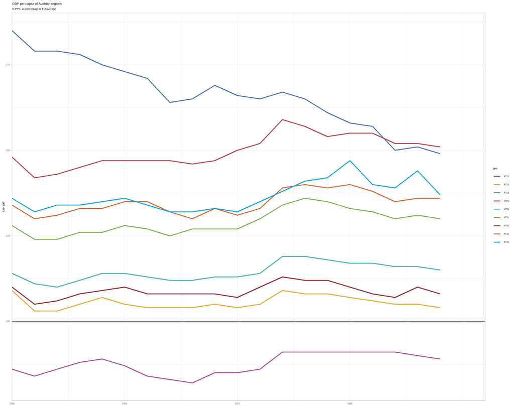

```r
p<- p + geom_hline(yintercept = 100,
                   color = "black")+
  scale_x_continuous(expand = c(0,0),
                     limits = c(2000, 2021),#make space for labels later
                     breaks = seq(2000, 2015, by = 5))
p
```

## {ggreppel}

There are too many lines to identify them well by colour. Another possibility is to use direct labels with `{ggrepel}`.

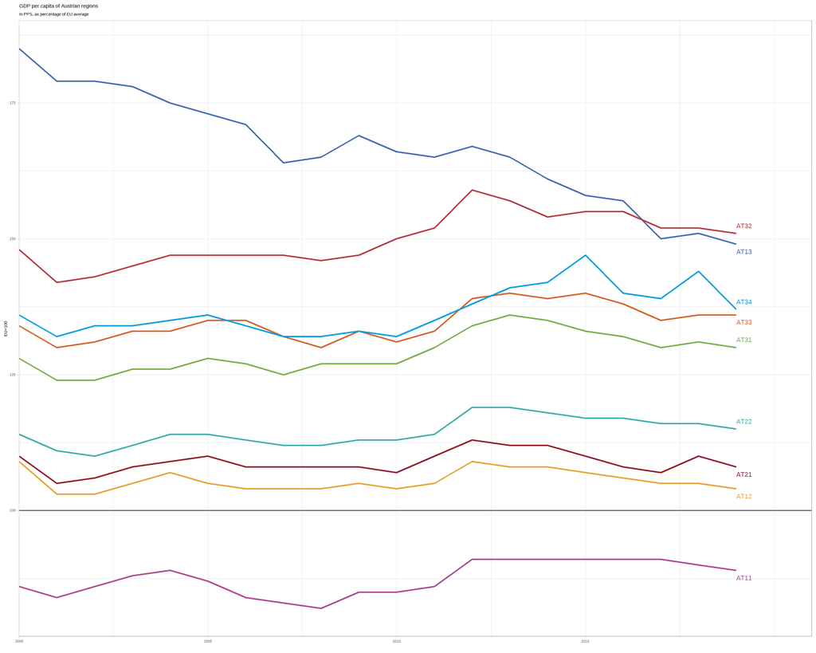

```r
library(ggrepel)
p <- p +   geom_text_repel(data= df %>% filter(time == 2019),# take last year only
    aes(label = geo),
    size = 6,
    direction = "y",
    hjust = 0,
    segment.size = 0.2,
     xlim = c(2019, 2021),
    segment.size = .4,
    segment.alpha = .5,
    segment.linetype = "dotted",
    box.padding = .4,
    segment.curvature = -0.1,
    segment.ncp = 3,
    segment.angle = 20
  )+
  theme(legend.position = "none")
p
```

## {gghighlight}

If we have too many lines it would be better to plot the data using facets and using `{gghightlight}`.

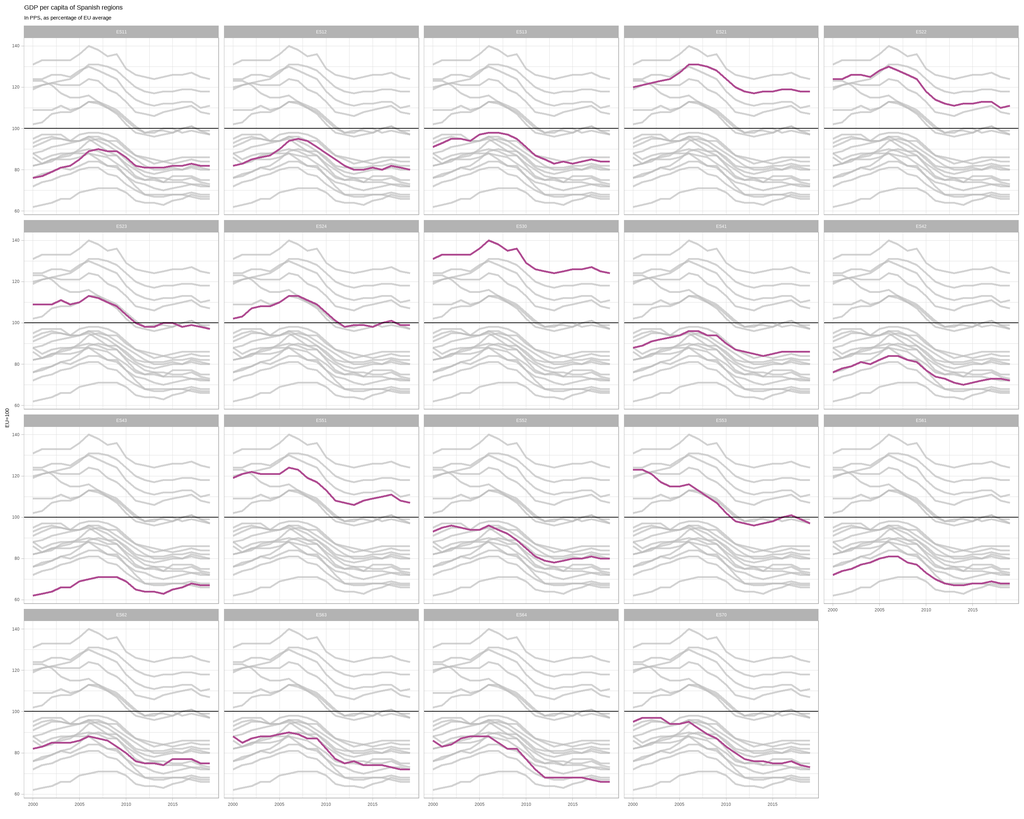

```r
library(gghighlight)

df <- data.table::fread("data/gdp2v.csv") %>%
  mutate( country = str_sub(geo,1,2),
          NUTS = str_length(geo)-2) %>%
  filter(country == "ES" & NUTS == "2" & unit == "PPS_HAB_EU27_2020")

ggplot( df, aes(x=time, y=obs_value,group = geo)) +
    geom_line(size = 1, colour = luis_cols("theme2")) +
    gghighlight(use_direct_label = FALSE)+
  geom_hline(yintercept = 100,
                   color = "black")+
  facet_wrap(~geo)+
  theme_light()+
    labs(y = "EU=100",
         x="",
       title = "GDP per capita of Spanish regions",
      subtitle =  "In PPS, as percentage of EU average")
```

## geom_rect

This could be a nice addition to shade some periods. For example when Spain converged.

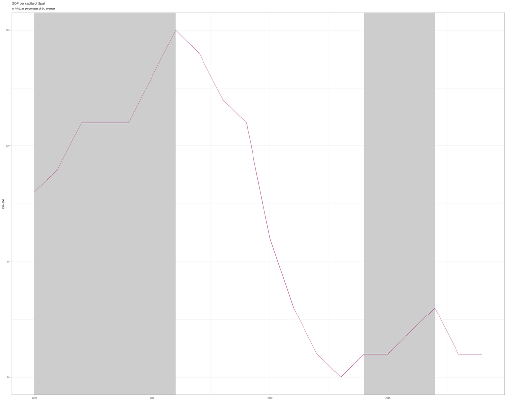

```r
df <- data.table::fread("data/gdp2v.csv") %>%
  filter(geo == "ES" & unit == "PPS_HAB_EU27_2020")


ggplot( df, aes(x=time, y=obs_value)) +
 geom_rect(aes(xmin=2000, xmax=2006, ymin=-Inf, ymax=+Inf), fill="#CCCCCC", alpha = 0.3)+
 geom_rect(aes(xmin=2014, xmax=2017, ymin=-Inf, ymax=+Inf), fill="#CCCCCC", alpha = 0.3)+
  geom_line(colour = luis_cols("theme2"))+
  theme_light()+
    labs(y = "EU=100",
         x="",
       title = "GDP per capita of Spain",
      subtitle =  "In PPS, as percentage of EU average")
```

## geom segment

It would be nicer to remove horizontal grid lines and add them later manually with `{geom_segment}`.

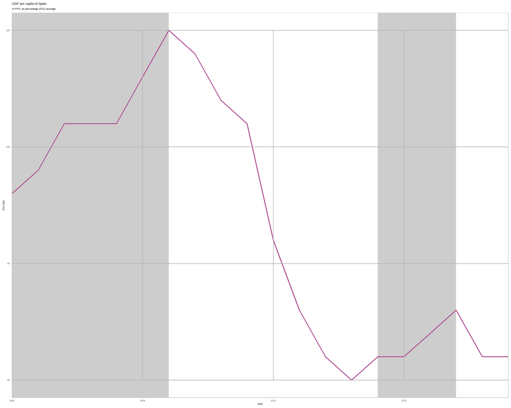

```r
ggplot( df, aes(x=time, y=obs_value)) +
 geom_rect(aes(xmin=2000, xmax=2006, ymin=-Inf, ymax=+Inf), fill="#CCCCCC", alpha = 0.3)+
 geom_rect(aes(xmin=2014, xmax=2017, ymin=-Inf, ymax=+Inf), fill="#CCCCCC", alpha = 0.3)+
  geom_line(colour = luis_cols("theme2"), size = 1)+
    labs(y = "EU=100",
       title = "GDP per capita of Spain",
      subtitle =  "In PPS, as percentage of EU average")+
  theme_light()+
    theme(panel.grid = element_blank(),
          panel.background = element_blank())+
 geom_segment(
    data = tibble(y = seq(90, 105, by = 5), x1 = 2000, x2 = 2019),
    aes(x = x1, xend = x2, y = y, yend = y),
    #inherit.aes = FALSE,
    color = "grey70",
    size = .6,
    )+
geom_segment(
    data = tibble(y1 = 90, y2 = 105, x =seq(2000,2019, by = 5)),
    aes(x = x, xend = x, y = y1, yend = y2),
    #inherit.aes = FALSE,
    color = "grey70",
    size = .6
    )+
    scale_x_continuous(expand=c(0,0))
```

## geom_ribbon and `{ggh4x}`

We can plot the are between a line and the axis lines.

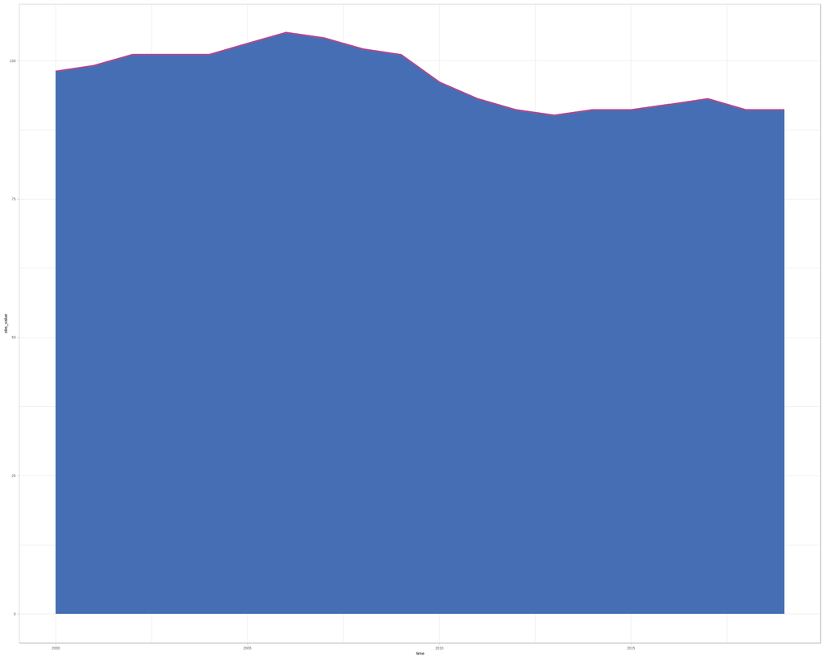

```r
df <- data.table::fread("data/gdp2v.csv") %>%
  filter(geo %in% c("ES") & unit == "PPS_HAB_EU27_2020")


ggplot( df, aes(x=time, y=obs_value)) +
  geom_line(size = 2,colour = luis_cols("theme2"))+
  geom_ribbon(aes(ymin = 0 , ymax = obs_value), fill = luis_cols("theme1"),)+
  theme_light()
```

A nicer feature is to colour the are between two lines with `{ggh4x}`. We need to re-arrange the dataset to wider.

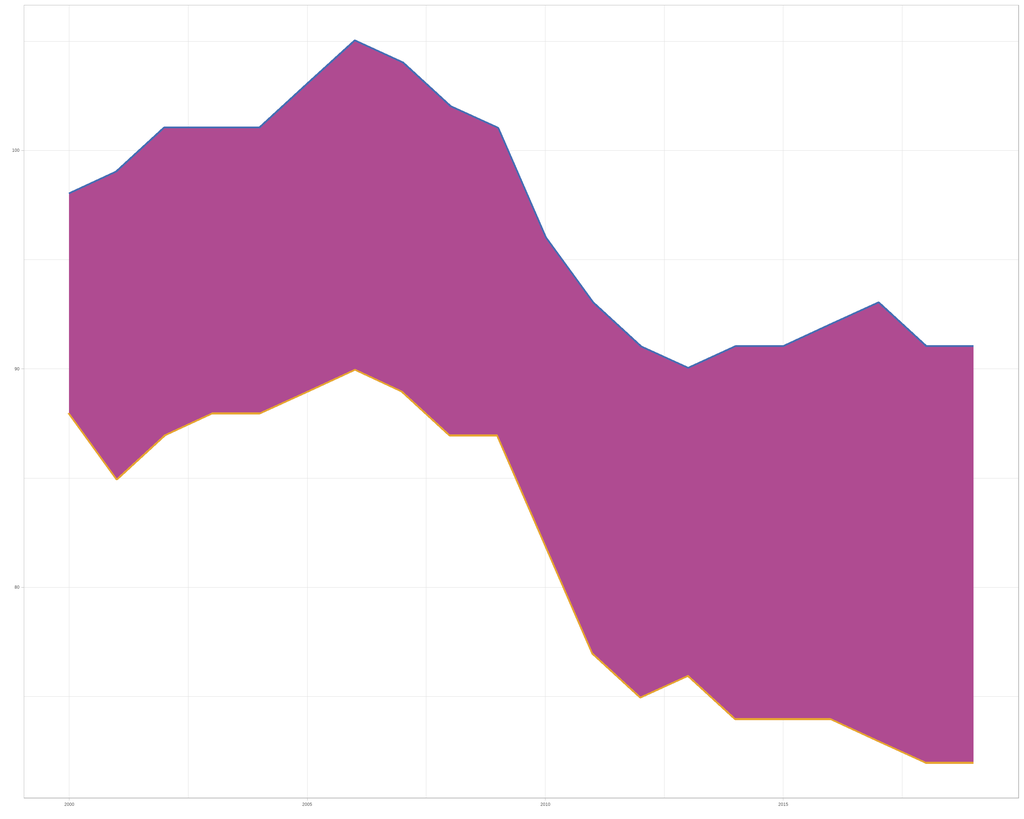

```r
df <- data.table::fread("data/gdp2v.csv") %>%
  filter(geo %in% c("ES", "ES63") & unit == "PPS_HAB_EU27_2020") %>%
  pivot_wider(names_from = geo,
        values_from = obs_value)


ggplot(df,aes(x=time)) +
  geom_line(aes(y = ES), size =2, colour = luis_cols("theme1"))+
  geom_line(aes(y = ES63), size=2, colour = luis_cols("theme3"))+
  geom_ribbon(aes(ymin = ES63 , ymax = ES), fill = luis_cols("theme2"))+
  theme_light()+
  labs(x="",
       y="",
       colour ="Geo")+
    scale_color_manual(breaks=c('Spain', 'Andalucía'),
                     values=c('Spain'=luis_cols("theme1"), 'Andalucia'=luis_cols("theme3")))+
  theme(legend.position = "bottom")
```